# Healthy Relationship Notebook

# Healthy Relationship Outcome

Relationship skills are a critical component of success in all realms of life. The Healthy Relationship questions measures the behaviors and attitudes of the respondent regarding their relationship skills. Questions that measure healthy relationships skills include the following:

*Healthy Relationship Questions*

1. If I have a serious problem, I have people to talk with.
2. I let people know if they have hurt my feelings.
3. I let my friends know when I think they are good at something.
4. In any relationship - romantic or not - I make it clear when I don’t feel comfortable.

## Pre Survey Analysis

The number of valid surveys entered is **570**, and the number of students achieving at a high level is **211** and that equates to **37.02%**. The average score from students is **3.85**

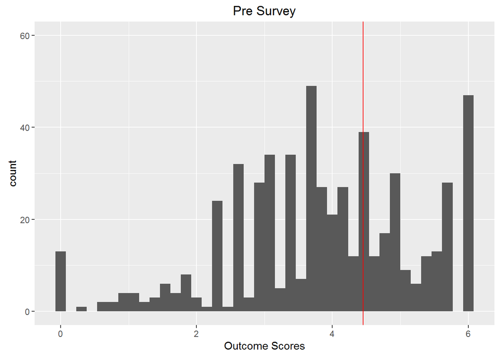

# Pre Survey Healthy Relationship History

| Year | population | percent_achieved | mean |
| --- | --- | --- | --- |
| 2013 | 699 | 61% | 4.55 |
| 2014 | 1186 | 61% | 4.44 |
| 2015 | 844 | 59% | 4.41 |

Cross Validation of Healthy Relationship Skills

# Pre Parent Survey

Question 5: She develops positive relationships with her classmates.

Results based on responses.

```
##   Item      low  neutral     high     mean       sd
## 1   Q5 7.276507 20.58212 72.14137 5.226611 1.337207
```

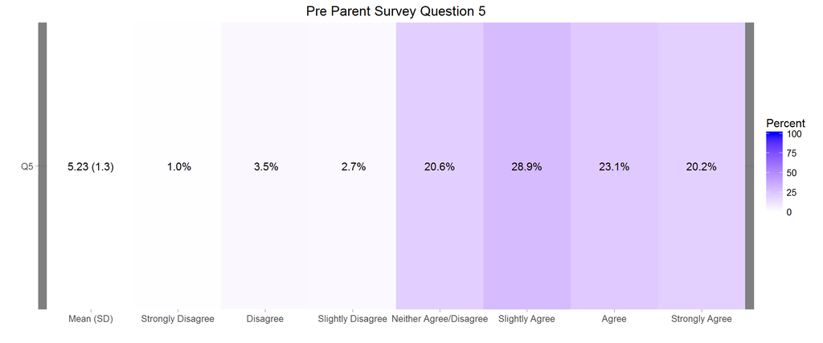

### Teacher Survey

```
##   Item      low neutral     high     mean       sd
## 1   Q7 11.58537 30.4878 57.92683 4.771341 1.260856
```

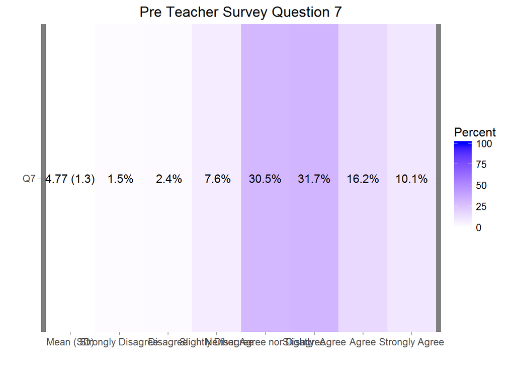